# Report Diffusion Accumulation

Geoffrey Megardon

12 October 2016

# 1 Addition of two sources of noise

Note that:
$$\alpha N(0,1) + \beta N(0,1) = \sqrt{\alpha^2 + \beta^2} N(0,1)$$

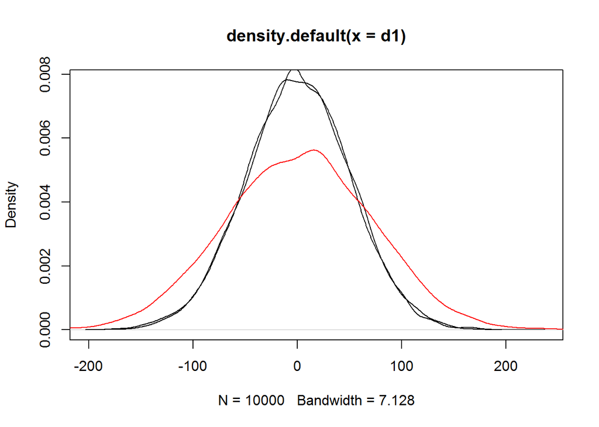

```r
d1 <- 50*rnorm(10000)
d2 <- 50*rnorm(10000)
d3 <- d2 + d1
plot(density(d1))
lines(density(d2))
lines(density(d3), col='red')
```

```r
var(d3)
```

```
## [1] 5037.577
```

```r
var(d1)
```

```
## [1] 2530.232
```

# 2 Bogacz’ and Trappenberg’s inclusion of noise in the model

Trappenberg et al. 2001 uses the equation:
$$\tau \frac{du}{dt} = -Lu + I + \alpha W_1$$
Where $W_1$ is a noise of mean 0 and variance 1, i.e. $N(0,1)$. Note that Bogazc et al. 2006 uses this:
$$du = (-Lu + I)dt + \alpha dW_1$$
That is:
$$\frac{du}{dt} = -Lu + I + \alpha \frac{dW_1}{dt}$$
Thus, in Bogacz et al. 2006, if L = 0 and I=0 (i.e. perfect accumulation, noise only):
$$u(t) = \alpha W_1(t)$$
While in Trappenbeg:
$$u(t) = \frac{\alpha}{\tau} \int_{t0}^{t} W_1(t)dt$$

Thus, in Bogacz et al.’ s equations, it seems that there is no accumulation of noise… ?

# 3 Accumulation of Noise in accumulation models

## 3.1 Solution of u(t)

Using the equation:
$$\tau \frac{du}{dt} = -Lu + I + \alpha W_1$$
Let simplify to:
$$\tau \frac{du}{dt} = -Lu + B$$
Using the method of Euler (as it is what we used):
$$u(t) = u(t-1) + \frac{1}{\tau}(-Lu(t-1) + B(t-1))\\
u(t) = \Big(1-\frac{L}{\tau}\Big)u(t-1) + \frac{1}{\tau}B(t-1)$$
Developping $u(t-1)$ further:
$$u(t) = \Big(1-\frac{L}{\tau}\Big)
\Bigg[ \Big(1-\frac{L}{\tau}\Big)u(t-2) + \frac{1}{\tau}B(t-2)\Bigg]
+ \frac{1}{\tau}B(t-1)$$
And $u(t-2)$ further:
$$u(t) = \Big(1-\frac{L}{\tau}\Big)
\Bigg[ \Big(1-\frac{L}{\tau}\Big)
\Bigg[ \Big(1-\frac{L}{\tau}\Big)u(t-3) + \frac{1}{\tau}B(t-3)\Bigg]
+ \frac{1}{\tau}B(t-2)\Bigg]
+ \frac{1}{\tau}B(t-1)$$
We obtain:
$$\Big(1-\frac{L}{\tau}\Big)^3u(t-3) + \frac{1}{\tau}B(t-1)
+ \frac{1}{\tau}\Big(1-\frac{L}{\tau}\Big)B(t-2) +\frac{1}{\tau}\Big(1-\frac{L}{\tau}\Big)^2B(t-3)$$
That can be written:
$$\Big(1-\frac{L}{\tau}\Big)^3u(t-3) + \frac{1}{\tau}\Big(1-\frac{L}{\tau}\Big)^0B(t-1)
+ \frac{1}{\tau}\Big(1-\frac{L}{\tau}\Big)^1B(t-2) +\frac{1}{\tau}\Big(1-\frac{L}{\tau}\Big)^2B(t-3)$$
Thus, we can see the following pattern:
$$u(t) = \Big(1-\frac{L}{\tau}\Big)^Nu(t-N) + \frac{1}{\tau}\sum_{s=1}^{N}\Big(1-\frac{L}{\tau}\Big)^{s-1}B(t-s)$$

if $N=t-t0$ and t0=0, we can write:
$$u(t) = \Big(1-\frac{L}{\tau}\Big)^t u(0)+ \frac{1}{\tau}\sum_{s=1}^{t}\Big(1-\frac{L}{\tau}\Big)^{s-1}B(t-s)$$

## 3.2 Continuous counter part:

The equation we are using is similar to the integrate and fire neuron model for which the continuous solution is well known:
$$u(t) = \exp\Big(-\frac{L}{\tau}t\Big)u(0) + \frac{1}{\tau} \int_{0}^{t}\exp\Big(-\frac{L}{\tau}s\Big)B(t-s)ds$$

Is the function $\Big(1-\frac{L}{\tau}\Big)^t$ equivalent to $\exp\Big(-\frac{L}{\tau}t\Big)$ ?

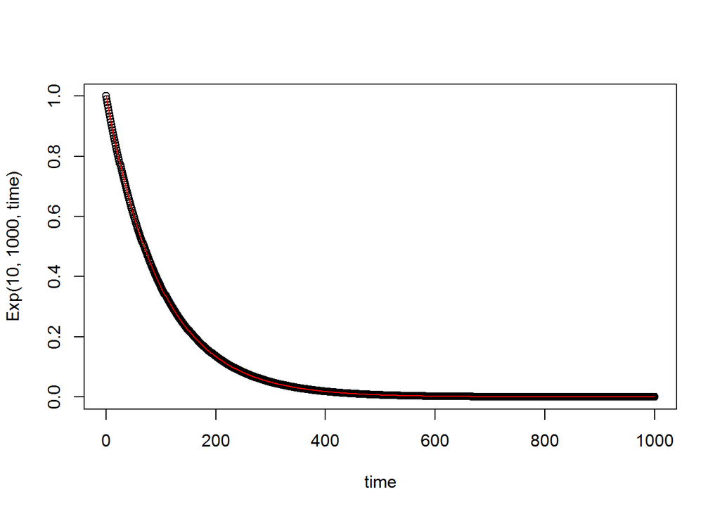

```r
almostExp <- function(L, tau, t){
  return ((1- L/tau)^t)
}

Exp <- function(L, tau, t){
  return (exp(-L*t/tau))
}

time <- 0:1000

plot(time, Exp(10, 1000, time))
points(time, almostExp(10, 1000, time), col='red', type='l')
```

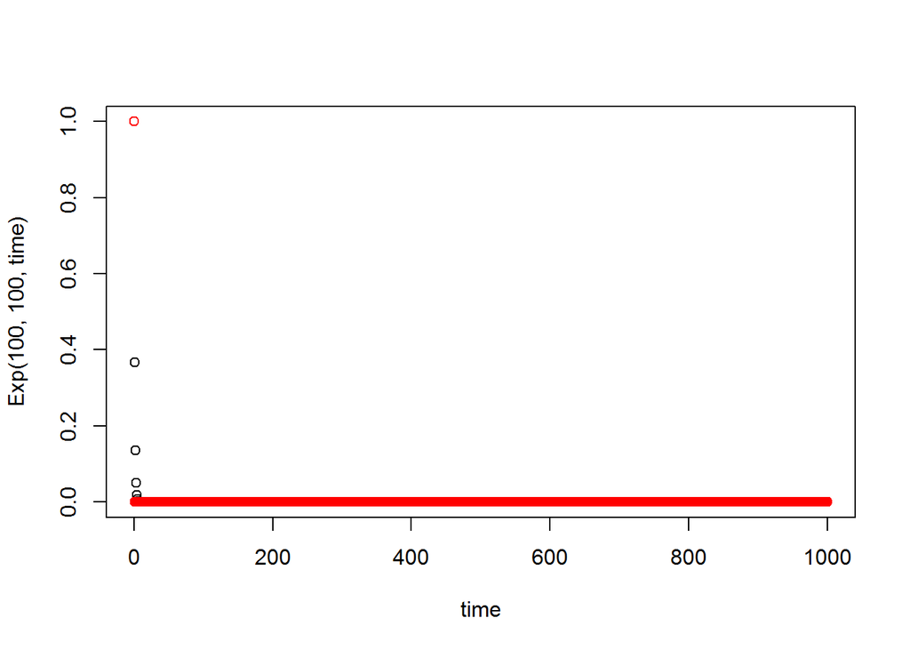

```r
plot(time, Exp(100, 100, time))
points(time, almostExp(100, 100, time), col='red')
```

Importantly note that when $\tau = L$, then $\Big(1-\frac{L}{\tau}\Big)^t = 1$ for $t=0$

## 3.3 What happen to noise for different value of L and $\tau$ ?

Setting $\tau > 1$ and $u(0) = 0$,

- If $L = \tau$:
  $$u(t) = \frac{1}{\tau}\sum_{s=1}^{t}\Big(0\Big)^{s-1}B(t-s)$$
  Remembering that $0^0 = 1$, we obtain:
  $$u(t) = \frac{1}{\tau}B(t-s)$$
  The value of u(t) is a perfect/instantaneous/exact copy of the input (or noise), scaled by $1/\tau$. **Thus, the variance of its noise does not accumulated, it stays to $\alpha$.**
- If $L = 0$:
  $$u(t) = \frac{1}{\tau}\sum_{s=1}^{t}B(t-s)$$
  That is a perfect accumulation, scaled by $1/\tau$. **Thus, its accumulated variance goes to infinity with time.**
- If $L<\tau$:
  $$u(t)= \frac{1}{\tau}\sum_{s=1}^{t}\Big(1-\frac{L}{\tau}\Big)^{s-1}B(t-s)\\$$
  is converging because:
  $$\lim_{t\to\infty} \Big(1-\frac{L}{\tau}\Big)^{s-1} = 0$$
  this also means that, although u(t) accumulate recent input, it forgets them with time (smaller weight with time). **Thus, its maximum accumulated variance is bounded. It stabilizes to a constant variance after a while. For instance, if only the 2 last time step have a strong effect, the variance will set to $\sqrt{\sqrt{\alpha^2 + \alpha^2} +\alpha^ 2} N(0,1)$ after the time step 3.**

In DINASAUR, the “memory” of u(t) is short compared to the simulation time. [As it makes 1200 steps (?) to simulate 1.2 second of real-time, we can state that $\tau=10$ is in millisecond.]

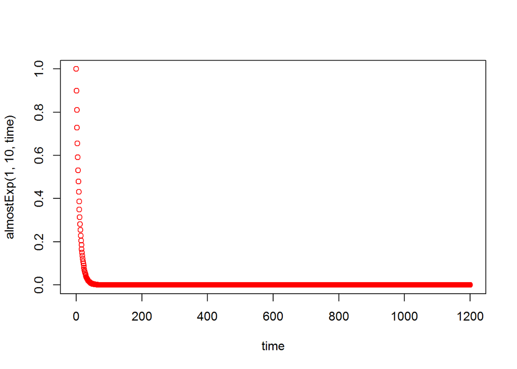

```r
almostExp <- function(L, tau, t){
  return ((1- L/tau)^t)
}

time <- 0:1200

plot(time, almostExp(1, 10, time), col='red')
```